# RStatsGDS_Clustering

James Sacco

4/3/2018

# Clustering

Manhattan or Taxi Cab distance |x1 - x2| + |y1 - y2|

Hierarchical clustering 1) find the two points that are closest together, and connect them (use the average between those points, the averages of the y and x values, to make a new data point) 2) find the next nearest distance, and iterate till all points are clustered 3) results is a cluster dendrogram

K-means clustering 1) where are the centers of the clusters? assign points to the closest centers, and assign all the points to their closest centers. now, recalculate where centers should be. starting values can change the clusters. clusters can be easily overinterpreted and overused.

```r
rm(list=ls())
```

```r
#suppress package messages
suppressPackageStartupMessages({
  library(devtools)
  library(Biobase)
  library(dendextend)
})


##---load--------------------------------------
library(gplots)
library(devtools)
library(Biobase)
library("RSkittleBrewer", lib.loc="/Library/Frameworks/R.framework/Versions/3.3/Resources/library")
library(org.Hs.eg.db)
library(AnnotationDbi)
library(dplyr)
library(dendextend)

#global palette
tropical=  c('darkorange', 'dodgerblue', 'hotpink', 'limegreen', 'yellow')
palette(tropical)

par(pch=19)
```

# General principles

How do we define close? How do we group things? How do we visualize the grouping? How do we interpret the grouping?

# Load some data

We will use this expression set to see how to use plots and tables to check for specific characteristics

```r
con =url("http://bowtie-bio.sourceforge.net/recount/ExpressionSets/bodymap_eset.RData")
load(file=con)
close(con)
bm = bodymap.eset
pdata=pData(bm)
edata=as.data.frame(exprs(bm))
fdata = fData(bm)
ls()
```

```
## [1] "bm"           "bodymap.eset" "con"          "edata"
## [5] "fdata"        "pdata"        "tropical"
```

Most important step -Garbage in -> garbage out Distance or similarity -Continuous - Euclidean distance -Continous - correlation similarity -Binary - manhattan distance

Pick a distance/similarity that makes sense for your problem

First we log transform and remove lowly expressed genes (require the mean count to be greater than 5000), then calculate Euclidean distance.

Add 1, so we don’t get undefined values

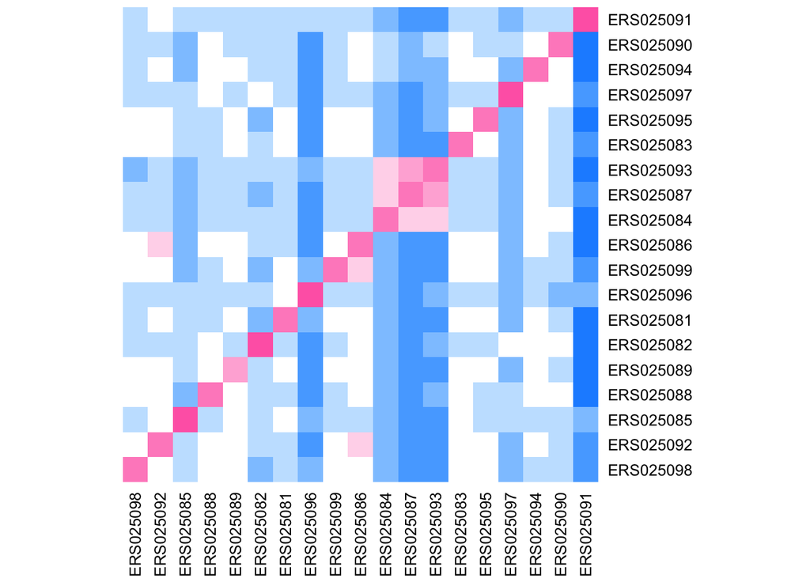

```r
edata = edata[rowMeans(edata) > 5000,]
edata = log2(edata + 1)


#Look at distance between either samples or genes.
#By default calculates the distance between rows.
#If you want the Euclidean distance between samples, then we transpose of the rows
dist1 = dist(t(edata))

##Look at distance matrix (heatmap between samples).
#The diagonal line is the distance between the sample and itself (obv. distance is very low)
#Samples that are closer are in white, while samples that are farther are in dark blue.

colramp = colorRampPalette(c(3,"white",2))(9)
heatmap(as.matrix(dist1),col=colramp,Colv=NA,Rowv=NA)
```

# Perform clustering

Hierarchical clustering use hclust function

```r
hclust1 = hclust(dist1)
```

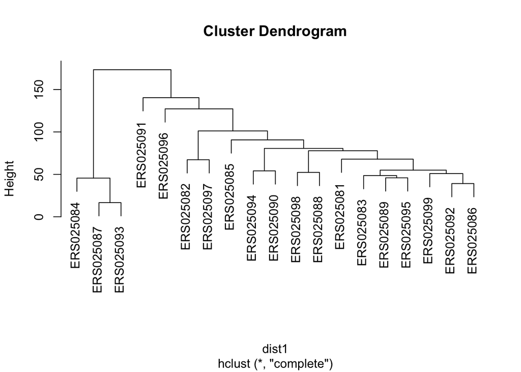

```r
plot(hclust1)
```

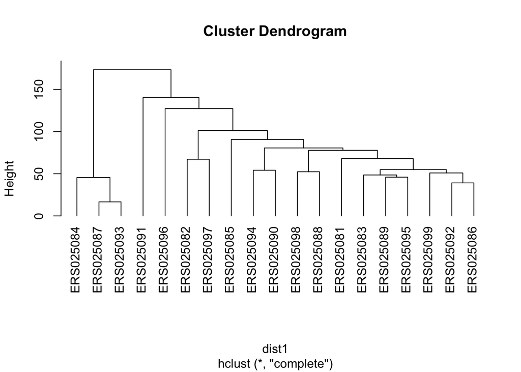

```r
plot(hclust1, hang=-1)
```

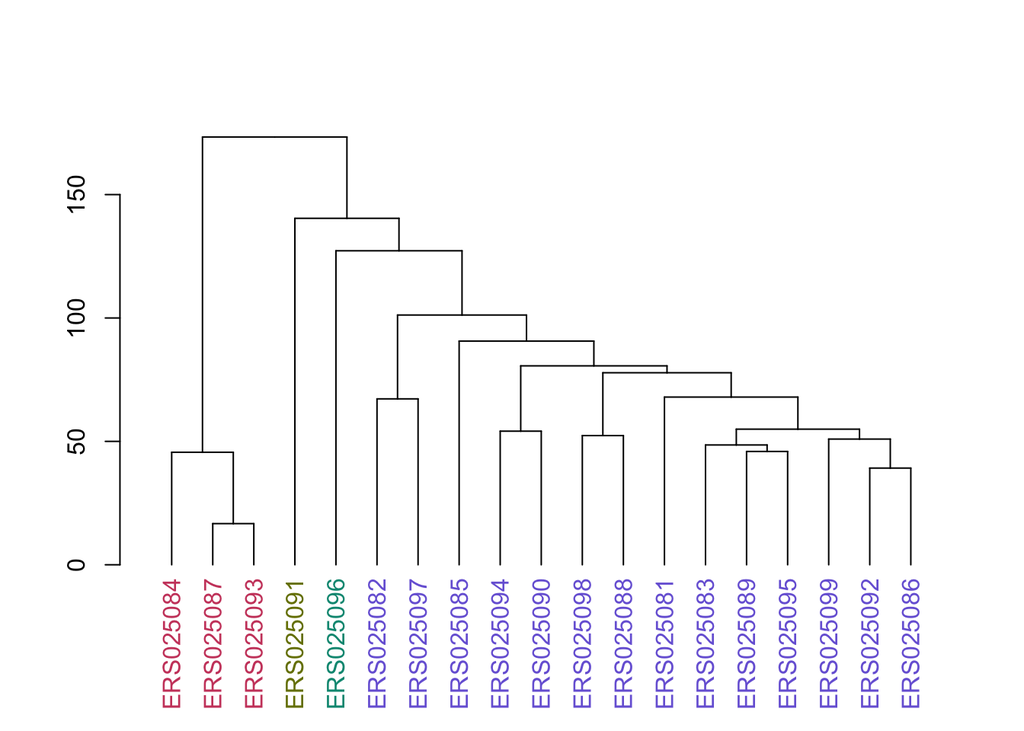

```r
dend = as.dendrogram(hclust1)
dend = color_labels(hclust1,4,1:4) #see 4 clusters
plot(dend)
```

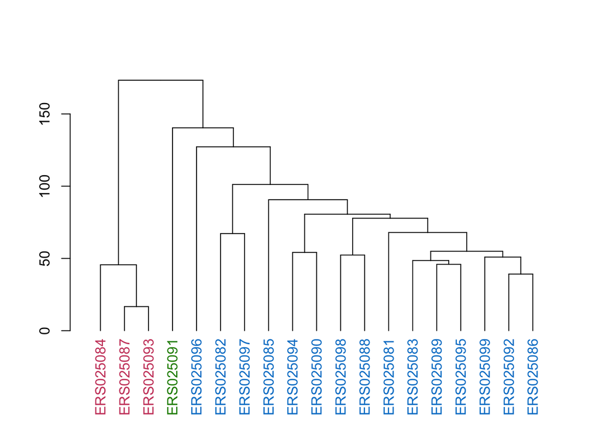

```r
dend = as.dendrogram(hclust1)
dend = color_labels(hclust1,3,1:3) #see 3 clusters
plot(dend)
```

```r
labels_colors(dend) = c(rep(1,10), rep(2,9)) #use to define what samples get what colors
```

# k-Means Clustering

```r
kmeans1 = kmeans(edata,centers=3)

names(kmeans1)
```

```
## [1] "cluster"      "centers"      "totss"        "withinss"
## [5] "tot.withinss" "betweenss"    "size"         "iter"
## [9] "ifault"
```

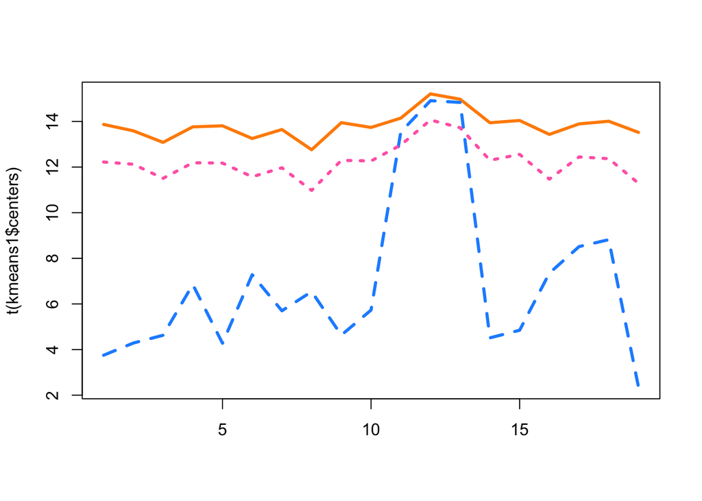

```r
matplot(t(kmeans1$centers),col=1:3, type = "l",lwd = 3)
```

```r
table(kmeans1$cluster)
```

```
##
##   1   2   3
## 396  63 739
```

```r
newdata = as.matrix(edata)[order(kmeans1$cluster),]
dim(newdata)
```

```
## [1] 1198   19
```

create heatmap of k-means cluster (genes similar to each other are clustered together)

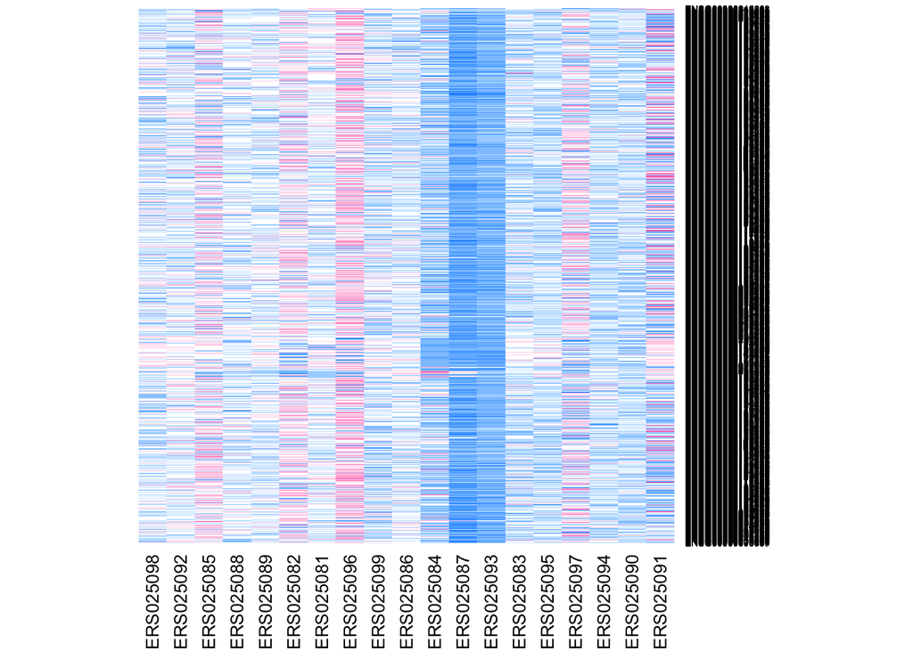

```r
heatmap(newdata,col=colramp,Colv = NA, Rowv = NA)
```

Note: this algorithms isn’t deterministic; it has a random start. so if you recalculate:

```r
kmeans2 = kmeans(edata,centers=3)
table(kmeans1$cluster, kmeans2$cluster)
```

```
##
##       1   2   3
##   1   0 396   0
##   2  32   0  31
##   3   0 720  19
```